# Exposome Data Integration with Omic Data

Carles Hernandez-Ferer and Juan R. Gonzalez

9 January 2017

#### Abstract

This is an introductory guide to integration analysis between exposome and omics data with R package rexposome. The document ilustrates two types of analysis: 1) Association analysis, that are performed between exposome and a single omic data-set; and 2) Integration analysis where multiple data-sets, including exposome data, are analysed at the same time.

#### Package version: rexposome 0.99.43

# 1 Introduction

## 1.1 Pipeline

## 1.2 Data Format

## 1.3 Installation

```r
devtools::install_github("carleshf/rexposome", ref="devel")
```

The methods provided by `rexposome` and used in this document relies in other existing Bioconductor packages. All association and integration methods requires a *MultiDataSet* object. The following are the R packages used in association analyses:

- *snpStats*
- *limma*
- *MEAL*

These are the packages used in the integration analyses:

- *omicade4*
- *[pma](http://cran.fhcrc.org/web/packages/pma/index.html)*

# 2 Analysis

**TEMP**: While `brgeDummyData` data package is not available, the data will be loaded using the current function:

```r
ldBRGE <- function(set) {
    path <- function(file) {
        prefix <- "C:/Users/carle/Desktop/rexposomeSupplementary/inma_sabadell"
        return(file.path(prefix, file))
    }
    sapply(set, function(nm) {
        pt <- NULL
        if(nm == "snp") {pt <- path("genome/snp.RData")}
        if(nm == "methy") {pt <- path("methylation/meth.RData")}
        if(nm == "gexp") {pt <- path("transcriptome/gexp_concordate_mset4.RData")}
        if(nm == "prot") {pt <- path("proteome/prot.RData")}

        load(pt, envir = .GlobalEnv)
    })
    invisible()
}
```

Under this sections two types of analysis are explained: **Association Analysis** and **Integration Analysis**.

Both types of analysis requests a `MultiDataSet` object. While **Association Analysis** are performed using a `MultiDataSet` object that contains an `ExposomeSet` plus a `SnpSet`, `MethylationSet` or `ExpressionSet`, **Integration Analysis** needs a `MultiDataSet` object with, at last, two of these objects.

## 2.1 Associaction Analysis

```r
library(rexposome)
library(MultiDataSet)
```

### 2.1.1 Exposome - Genome Data Associaction

The first step of an association analysis performed with `rexposome` is to create the `MultiDataSet` with the data to be analyzed.

The goal of this analysis is to perform a basic GWAS using the *phenotypes* stored in an `ExposomeSet`. Hence, a `MultiDataSet` with an `ExposomeSet` and a `SnpSet` is needed.

```r
data("exposome", package = "rexposome")
ldBRGE("snp")
```

```r
sampleNames(snp4) <- gsub("id", "SIMSAB", sampleNames(snp4))
```

Once the data is loaded a `MultiDataSet` object is created containing both data-sets:

```r
mds <- createMultiDataSet()
mds <- add_snps(mds, snp4)
mds <- add_exp(mds, expo)
```

After creating the `MultiDataSet` created the common samples between sets are kept and the others discarded:

```r
mds <- commonSamples(mds)
```

```r
mds
```

```
## Object of class 'MultiDataSet'
##  . assayData: 2 elements
##     . elements: snps, exposures
##  . featureData:
##     . snps: 817131 rows, 6 cols (chromosome, ..., allele.1)
##     . exposures: 104 rows, 8 cols (Family, ..., LOD)
##  . rowRanges:
##     . snps: YES
##     . exposures: NO
##  . phenoData:
##     . snps: 145 samples, 7 cols (pedigree, ..., affected)
##     . exposures: 145 samples, 5 cols (asthma, ..., age)
```

The association tests is done using the method `assocSNP`. The arguments of this method are:

```r
args(assocSNP)
```

```
## function (object, design, family = "binomial", filter.callrate = 0.98,
##     filter.maf = 0.05, filter.pvalHWE = 0.001, ...)
## NULL
```

The `object` argument is filled with the `MultiDataSet` object created previously. The `design` is a formula where the dependent variable are the genotypes and the dependent the *heath outcome*. `family` argument must indicate the type of the *heath outcome*.

The following are the *health outcomes* in the `ExposomeSet`:

```r
phenotypeNames(expo)
```

```
## [1] "asthma" "BMI"    "sex"    "age"
```

A GWAS for *asthma* using `assocSNP` is done as:

```r
gwas <- assocSNP(mds, asthma~sex+age)
```

The result is an object of class `ResultSet`:

```r
gwas
```

```
## Object of class 'ResultSet'
##  . created with: assocSNP
##  . original input: ExposomeSet, SnpSet
##     . names: exposures, snps
##  . #results: 1
##  . featureData:  2
##     . exposures: 104x8
##     . snps: 817131x6
```

This object allows to plot the results and draw a QQ plot and a Manhattan plot:

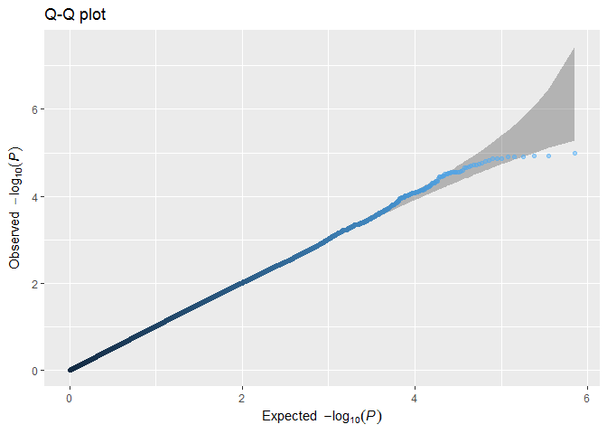

```r
plotAssociation(gwas, type="qq")
```

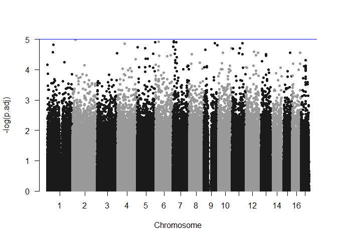

```r
plotAssociation(gwas, type="manhattan")
```

```r
head(extract(gwas))
```

```
##              Name      PVal       MAF     PValHWE
## 7579    rs1841925 0.0102700 0.4241379 0.001004813
## 90933  rs13228664 0.1226249 0.4241379 0.001004813
## 137030   rs636781 0.1859217 0.4241379 0.001004813
## 445724  rs1900627 0.6203369 0.4241379 0.001004813
## 540126  rs2074031 0.7546329 0.4241379 0.001004813
## 701103  rs2197088 0.9838075 0.4241379 0.001004813
```

### 2.1.2 Exposome - Methylome Data Associaction

The goal of this analysis is to perform an EWAS between the methylation levels and the exposures. To this end, a `MultiDataSet` with an `ExposomeSet` and a `MethylationSet` is required.

```r
data("exposome", package = "rexposome")
ldBRGE("methy")
```

```r
sampleNames(mset4) <- gsub("id", "SIMSAB", sampleNames(mset4))
```

Once the data is loaded a `MultiDataSet` object is created containing both data-sets:

```r
mds <- createMultiDataSet()
mds <- add_methy(mds, mset4)
mds <- add_exp(mds, expo)
```

After creating the `MultiDataSet` created the common samples between sets are kept and the others discarded:

```r
mds <- commonSamples(mds)
```

```r
mds
```

```
## Object of class 'MultiDataSet'
##  . assayData: 2 elements
##     . elements: methylation, exposures
##  . featureData:
##     . methylation: 476946 rows, 17 cols (chromosome, ..., Regulatory_Feature_Group)
##     . exposures: 104 rows, 8 cols (Family, ..., LOD)
##  . rowRanges:
##     . methylation: YES
##     . exposures: NO
##  . phenoData:
##     . methylation: 67 samples, 76 cols (Sample_Name, ..., Project)
##     . exposures: 67 samples, 5 cols (asthma, ..., age)
```

After obtaining the common samples, the association analysis between CpGs and exposures is done using `assocME`. This method requires a `MultiDataSet` object and a formula with the covariates. The optional argument `select` allows to perform the association on a sub-set of exposures (if `set = "exposures`) or sub-set of *outcomes*(if `set = "phenotypes"`).

```r
ewas <- assocME(mds, ~sex+age,
    select=c("logpb", "lcrCo_T1", "lTHM_T1", "Ben_preg", "garden_pesticides"))
```

The result is an object of class `ResultSet`:

```r
ewas
```

```
## Object of class 'ResultSet'
##  . created with: assocME
##  . original input: ExposomeSet, MethylationSet
##     . names: exposures, methylation
##  . #results: 5
##  . featureData:  2
##     . exposures: 104x8
##     . methylation: 476946x17
```

The raw results of the analysis can be obtained using the method `extract` and giving it the exposures of interest. If no exposure (or phenotype) is given, `extract` will return a table with the results for all the exposures (or phenotypes).

```r
head(extract(ewas, rid="garden_pesticides"))
```

```
##             intercept garden_pesticides1        sd         t      P.Value
## cg04875128 -6.3507415          1.4006607 0.2063285  6.788498 3.680671e-09
## cg17100201  4.5504626          0.7457214 0.1168835  6.380038 1.945166e-08
## cg01804351  3.2473027          0.9302233 0.1571957  5.917614 1.248101e-07
## cg07102368 -0.0107688          1.1621923 0.1982985  5.860823 1.564446e-07
## cg12727358  3.0017504         -1.5772612 0.2752346 -5.730606 2.620222e-07
## cg06614534  2.6548743          1.0210608 0.1788966  5.707547 2.869802e-07
##              adj.P.Val
## cg04875128 0.001755481
## cg17100201 0.004638695
## cg01804351 0.018653911
## cg07102368 0.018653911
## cg12727358 0.022812345
## cg06614534 0.022812345
```

The `ResultSet` can be used to plot the already seen QQ and Manhattan plots. Also a volcano plot.

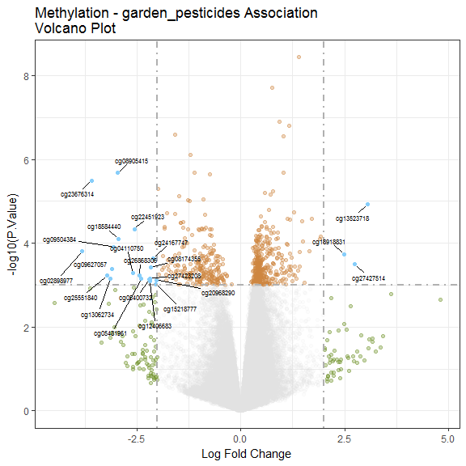

```r
plotAssociation(ewas, rid="garden_pesticides", type="volcano")
```

The same analysis can be done using an `ExposomeClust` instead of an `ExposomeSet`.

```r
data("eclust", package = "rexposome")
```

```r
mds <- createMultiDataSet()
mds <- add_methy(mds, mset4)
mds <- add_cls(mds, expo_c)
```

After creating the `MultiDataSet` the method `assocME` can be called directly. It will look for the common samples before running the association test.

```r
methy <- assocME(mds, ~sex+age)
methy
```

```
## Object of class 'ResultSet'
##  . created with: assocME
##  . original input: ExposomeClust, MethylationSet
##     . names: cluster, methylation
##  . #results: 1
##  . featureData:  2
##     . cluster: 99x8
##     . methylation: 476946x17
```

The results of the association analysis can be obtained using the tag `"cluster"` in the argument `rid` of `extract` method:

```r
head(extract(methy, rid="cluster"))
```

```
##            intercept    cluster         sd         t      P.Value
## cg02385848  1.502082 -0.4097846 0.06335260 -6.468316 1.359702e-08
## cg05187826  4.086110 -0.2147503 0.03871162 -5.547437 5.381966e-07
## cg13517886  3.368581 -0.2987114 0.05588531 -5.345078 1.181617e-06
## cg07026882  4.839865 -0.3025914 0.05803414 -5.214023 1.955946e-06
## cg04920535  6.147944 -0.2778070 0.05339694 -5.202676 2.042764e-06
## cg05575375  2.184062 -0.2131700 0.04165943 -5.116969 2.832625e-06
##              adj.P.Val
## cg02385848 0.006485043
## cg05187826 0.128345361
## cg13517886 0.187855882
## cg07026882 0.194857614
## cg04920535 0.194857614
## cg05575375 0.225168183
```

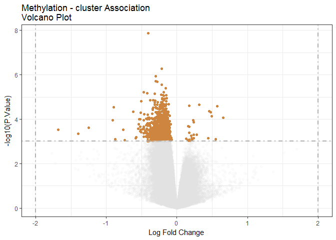

```r
plotAssociation(methy, rid="cluster", type="volcano")
```

### 2.1.3 Exposome - Transcriptome Data Associaction

The aim of this analysis is to perform an association test between the gene expression levels and the exposures. To this end, a `MultiDataSet` with an `ExposomeSet` and an `ExpressionSet` is required.

```r
data("exposome", package = "rexposome")
ldBRGE("gexp")
```

```r
sampleNames(gexp4) <- gsub("id", "SIMSAB", sampleNames(gexp4))
```

Once the data is loaded a `MultiDataSet` object is created containing both data-sets:

```r
mds <- createMultiDataSet()
mds <- add_genexp(mds, gexp4)
mds <- add_exp(mds, expo)
```

After creating the `MultiDataSet` created the common samples between sets are kept and the others discarded:

```r
mds <- commonSamples(mds)
```

```r
mds
```

```
## Object of class 'MultiDataSet'
##  . assayData: 2 elements
##     . elements: expression, exposures
##  . featureData:
##     . expression: 67528 rows, 11 cols (transcript_cluster_id, ..., gene_assignment)
##     . exposures: 104 rows, 8 cols (Family, ..., LOD)
##  . rowRanges:
##     . expression: YES
##     . exposures: NO
##  . phenoData:
##     . expression: 40 samples, 76 cols (Sample_Name, ..., Project)
##     . exposures: 40 samples, 5 cols (asthma, ..., age)
```

The association analysis between exposures and gene expression is done using the method `assocGE`. This method has the same behavior than `assocME`.

```r
gexp <- assocGE(mds, ~sex+age,
    select=c("logpb", "lcrCo_T1", "lTHM_T1", "Ben_preg", "garden_pesticides"))
```

The obtained object is also a `ResultSet`. The raw table can be obtained using `extract`:

```r
tt <- extract(gexp)
table(tt$exposure)
```

```
##
##          Ben_preg garden_pesticides          lcrCo_T1             logpb
##             67528             67528             67528             67528
##           lTHM_T1
##             67528
```

```r
head(tt[ , c("chromosome", "logFC", "P.Value", "adj.P.Val", "exposure")], n=5)
```

```
##                 chromosome      logFC      P.Value adj.P.Val exposure
## TC04001432.hg.1       chr4 -1.1640026 4.102022e-05 0.9998441    logpb
## TC16000213.hg.1      chr16 -0.8799460 5.783110e-05 0.9998441    logpb
## TC05001931.hg.1       chr5 -0.8479696 9.361022e-05 0.9998441    logpb
## TC11000437.hg.1      chr11  0.7386501 1.475673e-04 0.9998441    logpb
## TC12000180.hg.1      chr12 -1.0047499 1.819951e-04 0.9998441    logpb
```

And all three QQ, Manhattan and volcano plots can be dawn using `plotAssociation`:

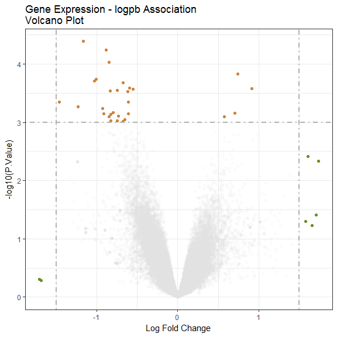

```r
plotAssociation(gexp, rid="logpb", type="volcano")
```

The same analysis can be done using an `ExposomeClust` instead of an `ExposomeSet`.

```r
data("eclust", package = "rexposome")
```

```r
mds <- createMultiDataSet()
mds <- add_genexp(mds, gexp4)
mds <- add_cls(mds, expo_c)
```

After creating the `MultiDataSet` the method `assocGE` can be called directly. It will look for the common samples before running the association test.

```r
gexp <- assocGE(mds, ~sex+age)
gexp
```

```
## Object of class 'ResultSet'
##  . created with: assocGE
##  . original input: ExposomeClust, ExpressionSet
##     . names: cluster, expression
##  . #results: 1
##  . featureData:  2
##     . cluster: 99x8
##     . expression: 67528x11
```

The results of the association analysis can be obtained using the tag `"cluster"` in the argument `rid` of `extract` method:

```r
head(extract(gexp, rid="cluster"))
```

[output not shown]

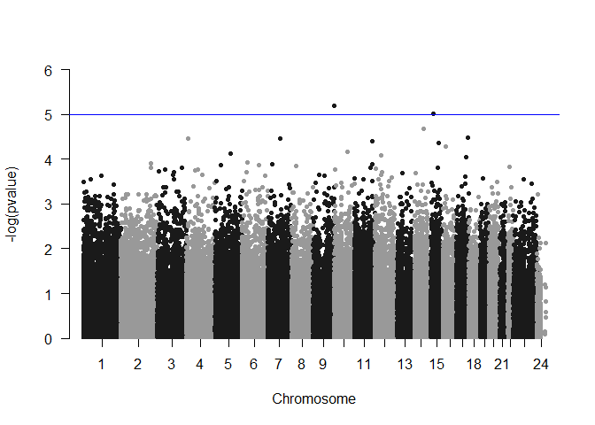

```r
plotAssociation(gexp, rid="cluster", type="manhattan")
```

### 2.1.4 Exposome - Proteome Data Associaction

The aim of this analysis is to perform an association test between the protein’ expression levels and the exposures. To this end, a `MultiDataSet` with an `ExposomeSet` and an `ExpressionSet` with protein expression data is required.

```r
data("exposome", package = "rexposome")
ldBRGE("prot")
```

Once the data is loaded a `MultiDataSet` object is created containing both data-sets:

```r
mds <- createMultiDataSet()
mds <- add_prot(mds, prot4)
mds <- add_exp(mds, expo)
```

After creating the `MultiDataSet`, the common samples between sets are kept and the others discarded:

```r
mds <- commonSamples(mds)
```

```r
mds
```

```
## Object of class 'MultiDataSet'
##  . assayData: 2 elements
##     . elements: protein, exposures
##  . featureData:
##     . protein: 47 rows, 2 cols (A, B)
##     . exposures: 104 rows, 8 cols (Family, ..., LOD)
##  . rowRanges:
##     . protein: NO
##     . exposures: NO
##  . phenoData:
##     . protein: 43 samples, 3 cols (A, ..., B)
##     . exposures: 43 samples, 5 cols (asthma, ..., age)
```

Ones obtained the common samples, the association analysis is done using `assocPRT`, that works like `assocME` and `assocGE`.

```r
prot <- assocPRT(mds, ~sex+age)
prot
```

```
## Object of class 'ResultSet'
##  . created with: assocPRT
##  . original input: ExposomeSet, ExpressionSet
##     . names: exposures, protein
##  . #results: 104
##  . featureData:  2
##     . exposures: 104x8
##     . protein: 47x2
```

As seen before the result of `assocPRT` is a `ResultSet` object which results can be ploted using `plotAssociation`.

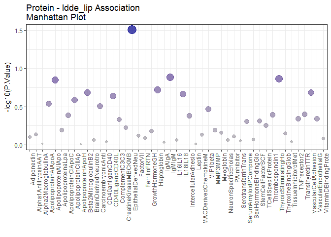

```r
plotAssociation(prot, rid="ldde_lip", type="manhattan")
```

The same analysis can be done using an `ExposomeClust` instead of an `ExposomeSet`.

```r
data("eclust", package = "rexposome")
```

```r
mds <- createMultiDataSet()
mds <- add_prot(mds, prot4)
mds <- add_cls(mds, expo_c)
```

After creating the `MultiDataSet` the method `assocPRT` can be called directly. It will look for the common samples before running the association test.

```r
prot <- assocPRT(mds, ~sex+age)
prot
```

```
## Object of class 'ResultSet'
##  . created with: assocPRT
##  . original input: ExposomeClust, ExpressionSet
##     . names: cluster, protein
##  . #results: 1
##  . featureData:  2
##     . cluster: 99x8
##     . protein: 47x2
```

The results of the association analysis can be obtained using the tag `"cluster"` in the argument `rid` of `extract` method:

```r
head(extract(prot, rid="cluster"))
```

```
##                       A         B      logFC   AveExpr        t
## Leptin               27  1.181715   2.012929   2.51000 4.327847
## MIP1beta             29 -1.129560 233.828724 382.97674 3.497565
## FerritinFRTN         19 -2.678545  14.944055  40.93023 2.881395
## PAInhibitor          33 -3.002530  44.645595 212.95349 2.742278
## TissueInhibitorofMet 42 -3.627169  19.338330 147.32558 2.459427
## IL18IL18             26 -3.796484 127.287207 348.13953 2.378697
##                           P.Value   adj.P.Val
## Leptin               0.0000999047 0.004695521
## MIP1beta             0.0011788100 0.027702036
## FerritinFRTN         0.0063754386 0.099881872
## PAInhibitor          0.0091293712 0.107270111
## TissueInhibitorofMet 0.0184034887 0.172375382
## IL18IL18             0.0223102972 0.172375382
```

And a Manhattan plot showing the association between the clustering and the protein levels of expression can be drawn:

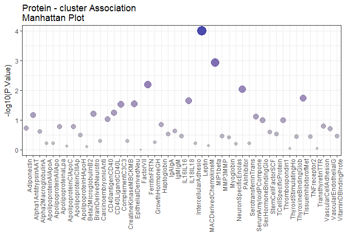

```r
plotAssociation(prot, rid="cluster", type="manhattan")
```

## 2.2 Integration Analysis

The aim on the integration analysis is to analyze multiple data-sets in a single shot, looking for similar behaviors in terms of features and through the data-sets. `rexposome` allows to perform this analysis using two strategies: *multiple co-inertia analysis* (`mcia`) and *sparse multiple canonical correlation analysis* (`mcca`).

To perform an integration analysis using exposome, transcriptome and proteome data a `MultiDataSet` object is required with the thee data-sets.

```r
data("exposome", package = "rexposome")
ldBRGE("gexp")
## ldBRGE("prot")
```

```r
sampleNames(gexp4) <- gsub("id", "SIMSAB", sampleNames(gexp4))
```

All the data-sets needs to be complete. So the exposures should be imputed:

```r
expo <- impute(expo)
```

```r
mds <- createMultiDataSet()
mds <- add_prot(mds, prot4)
mds <- add_genexp(mds, gexp4)
mds <- add_exp(mds, expo)
```

Once the data-sets is created, we look for the common samples.

```r
mds <- commonSamples(mds)
mds
```

```
## Object of class 'MultiDataSet'
##  . assayData: 3 elements
##     . elements: protein, ..., expression
##  . featureData:
##     . protein: 47 rows, 2 cols (A, B)
##     . expression: 67528 rows, 11 cols (transcript_cluster_id, ..., gene_assignment)
##     . exposures: 104 rows, 8 cols (Family, ..., LOD)
##  . rowRanges:
##     . protein: NO
##     . expression: YES
##     . exposures: NO
##  . phenoData:
##     . protein: 37 samples, 3 cols (A, ..., B)
##     . expression: 37 samples, 76 cols (Sample_Name, ..., Project)
##     . exposures: 37 samples, 5 cols (asthma, ..., age)
```

Both integration analysis are done using the method `crossomics`. The argument `method` can takes the values `"mcia"` and `"mcca"`.

```r
crs1 <- crossomics(mds, method="mcia")
```

```r
crs2 <- crossomics(mds, method="mcca")
```

```
## 12345678910111213141512345678
```

The method `crossomics` returns a `ResultSet` that can be used in the method `plotIntegration` to plot the results.

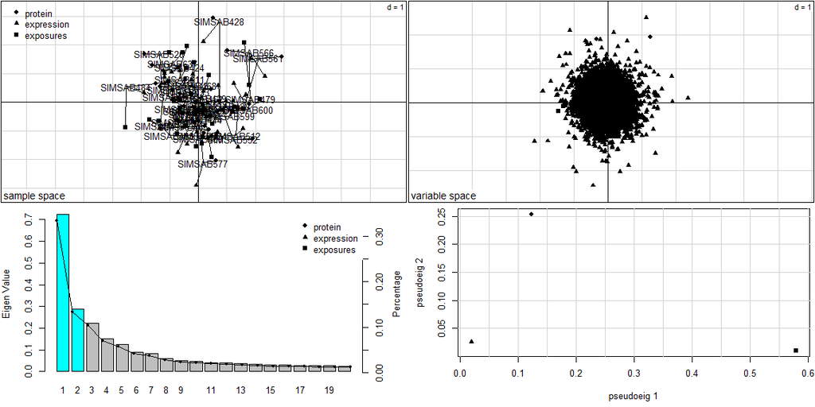

```r
plotIntegration(crs1)
```

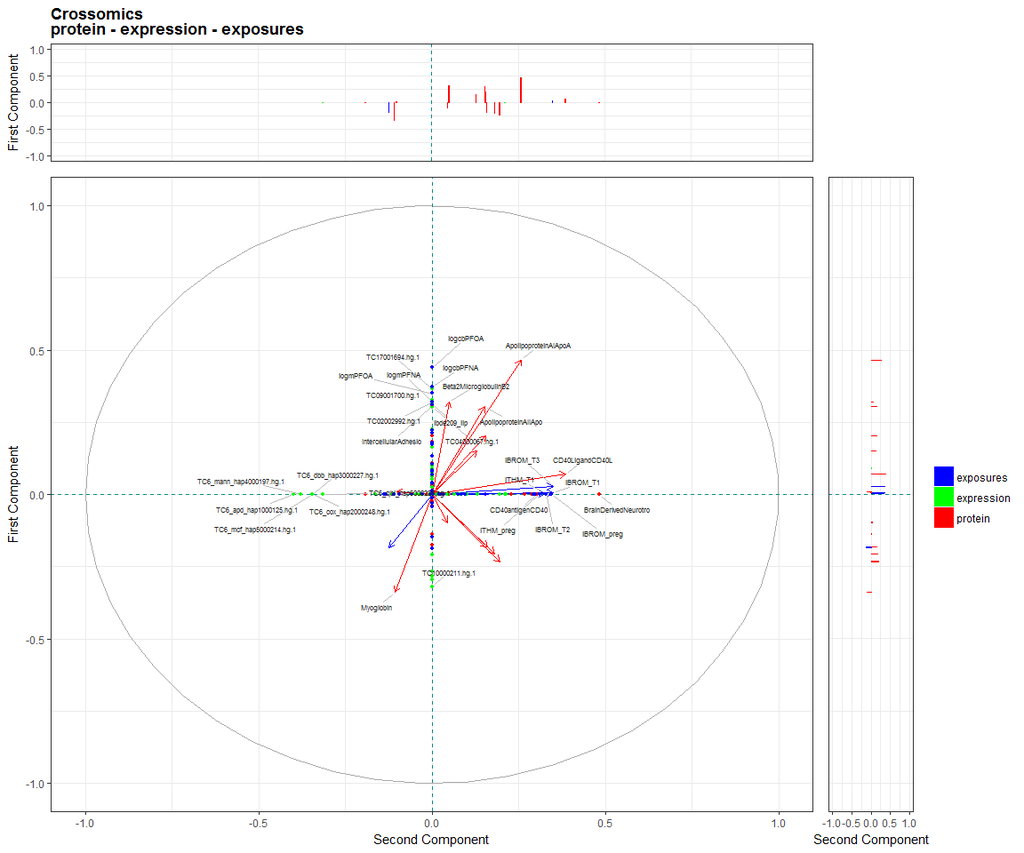

```r
plotIntegration(crs2, lb.th=0.3)
```